# Homework 3

Mohammad Manzoor Hassan Mirza

```r
library(ggplot2)
library(ISLR)
library(glmnet)
library(leaps)  # needed for regsubsets
library(boot)   # needed for cv.glm
library(MASS)
library(knitr)
library(gridExtra)
library(ggpubr)

cbPalette <- c("#999999", "#E69F00", "#56B4E9", "#009E73", "#F0E442", "#0072B2", "#D55E00", "#CC79A7")

options(scipen = 4)
```

The data use for the next few problems is about life expectancy and comes from [Kaggle](https://www.kaggle.com/kumarajarshi/life-expectancy-who)

### Question 1 - Variable selection

##### **(a)** Save the data file and set the working directory. Run the following code as it is. Look up what `rnorm()` function does. What’s contained in the additional columns we append to the original life expectancy dataset?

```r
set.seed(95791)

num.noise <- 50
lifexp <- read.csv("life_expentancy_who.csv")

df_lifexp <- data.frame(lifexp,
                   matrix(rnorm(num.noise * nrow(lifexp)),
                            nrow = nrow(lifexp)))

# Drop the non-numeric "country" column
df_lifexp = df_lifexp[,-1]
# Remove missing values
df_lifexp<-df_lifexp[complete.cases(df_lifexp), ]
head(df_lifexp)
```

```
##   Year Status Adult_Mortality infant_deaths Alcohol Percent_Expenditure
## 1 2015      0             263            62    0.01           71.279624
## 2 2014      0             271            64    0.01           73.523582
## 3 2013      0             268            66    0.01           73.219243
## 4 2012      0             272            69    0.01           78.184215
## 5 2011      0             275            71    0.01            7.097109
## 6 2010      0             279            74    0.01           79.679367
##   HepatitisB Measles  BMI under_five_deaths Polio Total.expenditure Diphtheria
## 1         65    1154 19.1                83     6              8.16         65
## 2         62     492 18.6                86    58              8.18         62
## 3         64     430 18.1                89    62              8.13         64
## 4         67    2787 17.6                93    67              8.52         67
## 5         68    3013 17.2                97    68              7.87         68
## 6         66    1989 16.7               102    66              9.20         66
##   HIV_AIDS       GDP Population thinness._1_19_yrs thinness_5_9_yrs Income_comp
```

[output cut: 69 more lines]

Your response here: The rnorm function runs a simulation to generate random variables given a certain distribution. We have added 50 columns of random noise variables with number of values in each equal to the number of rows in the life expectancy data. A total of 146,900 values have been added to the original life expectancy dataset.

##### **(b)** Use the `glm` command to fit a linear regression of `Life_expectancy` on all the other variables in the `df_lifexp` data set. Print the names of the predictors whose coefficient estimates are statistically significant at the 0.05 level. Are any of the “noise” predictors statistically significant?

**Hint:** To access the P-value column of a fitted model named `my.fit`, you’ll want to look at the `coef(summary(my.fit))` object.

```r
glm.fit <- glm(Life_expectancy ∼ ., data = df_lifexp)

summary(glm.fit)$coefficients[summary(glm.fit)$coefficients[, 4] <= 0.05, 0]
```

```
##
## (Intercept)
## Year
## Status
## Adult_Mortality
## infant_deaths
## Alcohol
## BMI
## under_five_deaths
## Total.expenditure
## Diphtheria
## HIV_AIDS
## Income_comp
## Schooling
```

Your response here: There are no random noise variables which are statistically significant. There are a total of 13 variables which are statistically significant here.

##### **(c)** Use the `cv.glm` command with 10-fold cross-validation to estimate the test error of the model you fit in part (a). Repeat with number of folds `K = 2, 5, 10, 20, 50, 100` (to make your code more concise and readable, use a loop to iterate over these choices of $K$).

**Note 1**: This question does NOT ask you to code your CV routine all over again. `cv.glm` automatically handles the CV of the model. You are only asked to try it with different choices of K listed above, which you will use a simple for-loop to do.

**Note 2**: This loop may take a few minutes to run. I have supplied the option cache = TRUE in the code chunk header to prevent the code from needing to re-execute every time you knit. This code chunk will re-execute only if the code it contains gets changed.

```r
set.seed(1)
folds <- c(2, 5, 10, 20, 50, 100)

result <- data.frame(matrix(ncol = 2, nrow = 0))

for (i in 1:6) {
  cv.error = cv.glm(df_lifexp, glm.fit, K = folds[i])$delta[1]
  result <- rbind (result, c(folds[i], cv.error))
}

colnames(result) <- c("K", "Test Error")

result
```

```
##     K Test Error
## 1   2   13.96984
## 2   5   13.42020
## 3  10   13.47632
## 4  20   13.38787
## 5  50   13.36285
## 6 100   13.39403
```

##### **(d)** Calculate the standard deviation of your CV error estimates across 6 different choices of $K$. Then calculate the mean of your CV error estimates. And finally take the ratio of the standard deviation and the mean (i.e. divide the standard deviation by the mean). This quantity is called the [coefficient of variation](https://en.wikipedia.org/wiki/Coefficient_of_variation). Do the CV error estimates change much across the different choices of $K$?

```r
coef_of_var <- sd(result$`Test Error`)/mean(result$`Test Error`)
```

Your response here: The coefficient of variation is 0.0172194. No, the cv error estimates do not change much across different values of k.

### Best subset selection

##### **(e)** The code below performs Best Subset Selection to identify which variables in the model are most important. We only go up to models of size 5, because beyond that the computation time starts to get excessive.

##### Which variables are included in the best model of each size? (You will want to work with the `summary(lifexp.subset)` or `coef(lifexp.subset, id = )` object to determine this.) Are the models all nested? That is, does the best model of size $k-1$ always a subset of the best model of size $k$? Do any “noise predictors” appear in any of the models?

```r
# Best subset selection

lifexp.subset <- regsubsets(Life_expectancy ~ .,
               data = df_lifexp,
               nbest = 1,    # 1 best model for each number of predictors
               nvmax = 5,    # NULL for no limit on number of variables
               method = "exhaustive", really.big = TRUE)

# Add code below to answer the question
lifexp.subset_sum<-summary(lifexp.subset)
lifexp.subset_sum
```

```
## Subset selection object
## Call: regsubsets.formula(Life_expectancy ~ ., data = df_lifexp, nbest = 1,
##     nvmax = 5, method = "exhaustive", really.big = TRUE)
## 70 Variables  (and intercept)
##                     Forced in Forced out
## Year                    FALSE      FALSE
## Status                  FALSE      FALSE
## Adult_Mortality         FALSE      FALSE
## infant_deaths           FALSE      FALSE
## Alcohol                 FALSE      FALSE
## Percent_Expenditure     FALSE      FALSE
## HepatitisB              FALSE      FALSE
## Measles                 FALSE      FALSE
## BMI                     FALSE      FALSE
## under_five_deaths       FALSE      FALSE
## Polio                   FALSE      FALSE
## Total.expenditure       FALSE      FALSE
## Diphtheria              FALSE      FALSE
## HIV_AIDS                FALSE      FALSE
## GDP                     FALSE      FALSE
## Population              FALSE      FALSE
## thinness._1_19_yrs      FALSE      FALSE
## thinness_5_9_yrs        FALSE      FALSE
## Income_comp             FALSE      FALSE
## Schooling               FALSE      FALSE
## X1                      FALSE      FALSE
## X2                      FALSE      FALSE
## X3                      FALSE      FALSE
## X4                      FALSE      FALSE
## X5                      FALSE      FALSE
## X6                      FALSE      FALSE
## X7                      FALSE      FALSE
## X8                      FALSE      FALSE
## X9                      FALSE      FALSE
## X10                     FALSE      FALSE
## X11                     FALSE      FALSE
## X12                     FALSE      FALSE
## X13                     FALSE      FALSE
## X14                     FALSE      FALSE
## X15                     FALSE      FALSE
```

[output cut: 64 more lines]

```
## 3  ( 1 ) " " " " " " " " " " " " " " " " " " " " " " " " " " " " " " " " " "
## 4  ( 1 ) " " " " " " " " " " " " " " " " " " " " " " " " " " " " " " " " " "
## 5  ( 1 ) " " " " " " " " " " " " " " " " " " " " " " " " " " " " " " " " " "
##          X30 X31 X32 X33 X34 X35 X36 X37 X38 X39 X40 X41 X42 X43 X44 X45 X46
## 1  ( 1 ) " " " " " " " " " " " " " " " " " " " " " " " " " " " " " " " " " "
## 2  ( 1 ) " " " " " " " " " " " " " " " " " " " " " " " " " " " " " " " " " "
## 3  ( 1 ) " " " " " " " " " " " " " " " " " " " " " " " " " " " " " " " " " "
## 4  ( 1 ) " " " " " " " " " " " " " " " " " " " " " " " " " " " " " " " " " "
## 5  ( 1 ) " " " " " " " " " " " " " " " " " " " " " " " " " " " " " " " " " "
##          X47 X48 X49 X50
## 1  ( 1 ) " " " " " " " "
## 2  ( 1 ) " " " " " " " "
## 3  ( 1 ) " " " " " " " "
## 4  ( 1 ) " " " " " " " "
## 5  ( 1 ) " " " " " " " "
```

```r
result <- list()

for(i in 1:5) {
result[[i]] <- c(coef(lifexp.subset, i))
}

result
```

```
## [[1]]
## (Intercept)   Schooling
##   41.550342    2.289787
##
## [[2]]
## (Intercept)    HIV_AIDS   Schooling
##  46.5832658  -0.6688794   1.9840119
##
## [[3]]
##     (Intercept) Adult_Mortality        HIV_AIDS       Schooling
##     53.52403637     -0.02158734     -0.45221739      1.67548775
##
## [[4]]
##     (Intercept) Adult_Mortality        HIV_AIDS     Income_comp       Schooling
##     52.52858503     -0.01952667     -0.44212068     11.76169628      1.11448197
##
## [[5]]
##         (Intercept)     Adult_Mortality Percent_Expenditure            HIV_AIDS
##       53.4481737565       -0.0190929232        0.0004145969       -0.4475558385
##         Income_comp           Schooling
##       11.0740235632        1.0454003939
```

Your response here: Yes, the models are nested since model size 4 is a subset of model size 5, model size 3 is a subset of model size 4 and so on. However, we do not see any noise predictors appearing in the model.

### Forward Stepwise Selection

##### **(f)** Modify the code provided in part (e) to perform Forward stepwise selection instead of exhaustive search. There should be no limit on the maximum size of subset to consider.

```r
lifexp.fwd <-  regsubsets(Life_expectancy ~ .,
               data = df_lifexp,
               nbest = 1,
               nvmax = NULL,
               method = "forward", really.big = TRUE)
```

##### **(g)** Run `summary()` on the `regsubsets` object you got above and save the output object as `lifexp.summary`. You saw in Lab 3 Part 2(f) that this summary object contains a bunch of useful values such as $R^2$, RSS, AIC, and BIC. Generate the four plots as you did in the lab and indicate the *“optimal”* models on each of the curves using `geom_point.` Interpret your results.

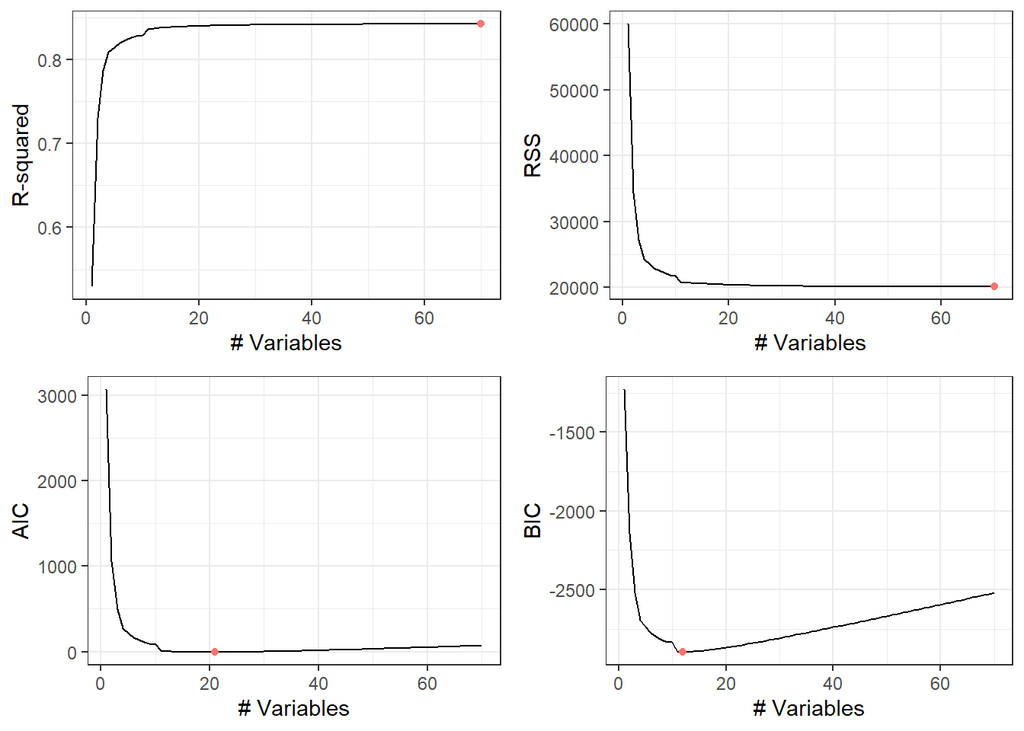

```r
lifexp.summary <- summary(lifexp.fwd)

num_variables <- seq(1, length(lifexp.summary$rss))

#Plotting R-squared

plot_RSQ <-ggplot(data = data.frame(lifexp.summary$rsq),
                 aes(x = num_variables, y = lifexp.summary$rsq)) +
  geom_line() +
  geom_point (x = which.max(lifexp.summary$rsq),
              y = max(lifexp.summary$rsq),aes(color="red"),
              show.legend = FALSE) +
  xlab("# Variables") +
  ylab("R-squared") +
  theme_bw()

#Plotting RSS

plot_RSS <-ggplot(data = data.frame(lifexp.summary$rss),
                 aes(x = num_variables, y = lifexp.summary$rss)) +
  geom_line() +
  geom_point (x = which.min(lifexp.summary$rss),
              y = min(lifexp.summary$rss), aes(color="red"),
              show.legend = FALSE) +
  xlab("# Variables") +
  ylab("RSS") +
  theme_bw()

#Plotting BIC

plot_BIC <- ggplot(data = data.frame(lifexp.summary$bic),
                 aes(x = num_variables, y = lifexp.summary.bic)) +
  geom_line() +
  geom_point (x = which.min (lifexp.summary$bic),
              y = min (lifexp.summary$bic), aes(color="red"),
              show.legend = FALSE) +
  xlab("# Variables") +
  ylab("BIC") +
  theme_bw()

#Plotting AIC

plot_AIC <- ggplot(data = data.frame(lifexp.summary$cp),
                   aes(x=num_variables,y = lifexp.summary.cp))+
  geom_line()+
  geom_point(x=which.min(lifexp.summary$cp),
             y=min(lifexp.summary$cp),aes(color="red"),
             show.legend = FALSE)+
  xlab("# Variables")+
  ylab("AIC")+
  theme_bw()

grid.arrange(plot_RSQ, plot_RSS, plot_AIC,plot_BIC, ncol=2,nrow=2)
```

### Question 2 - Lasso

> For the Lasso problems below, you may find it helpful to review the code examples in the [Linear regression with glmnet](https://web.stanford.edu/~hastie/glmnet/glmnet_alpha.html#lin) vignette. Running the glmnet command `glmnet(x = X, y = y)` where `y` is your response vector and `X` is your covariates matrix will fit a Lasso.

##### **(a)** Use the `glmnet` command to fit a Lasso to this data. Call the result `lifexp.lasso`.

```r
#covariates matrix
x.vars <- as.matrix(df_lifexp[, -21])
#response variable
y.var <- df_lifexp$Life_expectancy

lifexp.lasso <- glmnet(x = x.vars, y = y.var, alpha = 1)
```

##### **(b)** It turns out that `lifexp.lasso` contains model fits for an entire sequence of $\lambda$ values. Look at the `lifexp.lasso$lambda` attribute. How many $\lambda$ values do we have model fits for?

```r
length(lifexp.lasso$lambda)
```

```
## [1] 81
```

##### **(c)** Run the `plot` command on your `lifexp.lasso` object to get a regularization plot. Review the help file for `plot.glmnet` to figure out how to set “norm” as the x-axis variable option, and how to add labels to the curves. In this parameterization of the x-axis, is the model fit getting more complex or less complex as the x-axis variable increases?

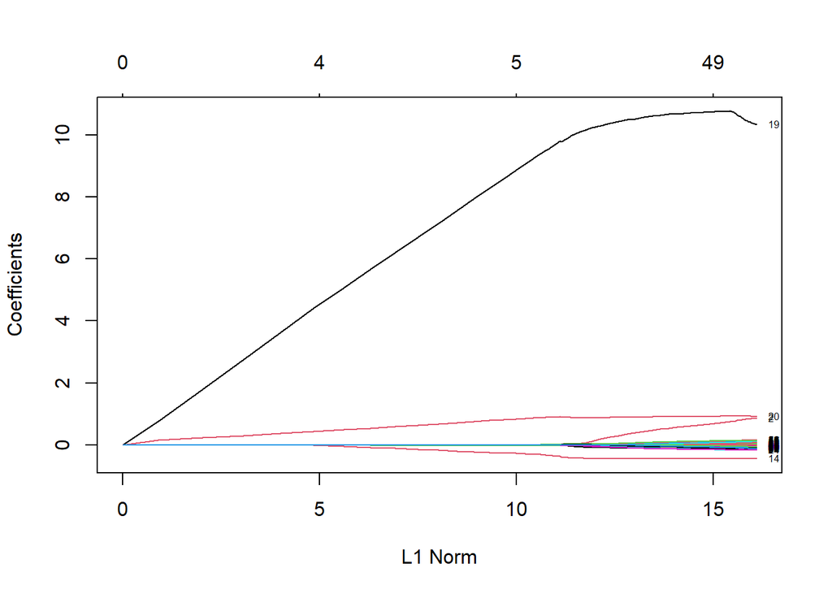

```r
plot(lifexp.lasso, xvar = "norm", label = TRUE)
```

Your response here: As the x-axis variable increases, the model fit becomes more complex i.e. more variables are added since the coefficients move away from zero.

### Question 3 - Instability of Logistic regression

> This question walks you through a simple example that illustrates the instability of logistic regression coefficient estimates in cases where the classes are **clearly separable**. This instability can arise in practice when we have inputs $X$ that are categorical variables with a large number of levels. In such cases, particularly when we have low cell counts, it is not uncommon for all observed outcomes in a particular category to be either all $0$ or all $1$. This leads the coefficient corresponding to that category to be very unstable.

##### **(a)** Load the `age.data` below, which contains simulated age information on 3000 individuals. We want to use the `age` variable to try to classify individuals as adults or non-adults. The outcome variable `is.adult` is 1 for adults and 0 for non-adults.

```r
age.data <- read.csv("agedata.csv")
```

##### Use `geom_histogram()` to construct a conditional probability plot to show how the probability of being an adult varies with age. You may check out the `geom_histogram(position = "fill")` example (at this link)[https://ggplot2-book.org/statistical-summaries.html]. Note that `fill` needs to take a factor variable, so you will need to convert the numeric `is.adult` to a factor *just for the purpose of this plot* (do not overwrite the original `is.adult` data).

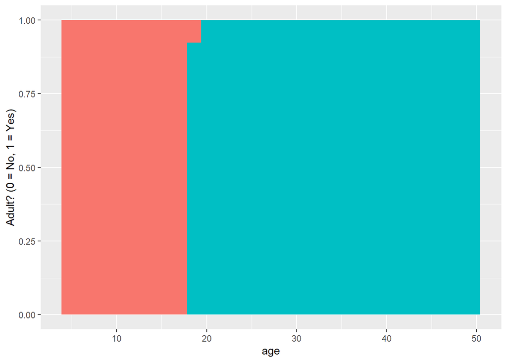

```r
ggplot(age.data, aes(age)) + geom_histogram(aes(fill = as.factor(is.adult)), position = "fill") +
  theme(legend.position = "none") +
  ylab("Adult? (0 = No, 1 = Yes)")
```

##### **(b)** Is this a difficult classification problem? Can you think of a simple rule that gives 100% classification accuracy for this task? Use your simple rule to try and classify the observations in data as adults (predict 1) or non-adults (predict 0). Compute the error rate of your prediction.

```r
rule.probs <- ifelse(age.data$age >= 18, 1, 0)
mean(rule.probs != age.data$is.adult)
```

```
## [1] 0
```

Your response here: This is not really a difficult classification problem since only one factor comes into play. I used a cutoff value of 18 which gives me a 100% classification accuracy. The reason is because this age is used to defined adulthood in the United States and many other countries across the world.

##### **(c)** Fit a logistic regression to the data. Use the `kable()` command to print out a nice summary of your coefficients estimate table. Is the coefficient of `age` statistically significant?

**Note:** You may encounter some warning messages when you fit the logistic regression, which is fine. In fact, these warnings are indicative of the exact problem with the data we are trying to demonstrate.

```r
log.fit <- glm(is.adult ~ age, family = binomial(), data = age.data)
```

```
## Warning: glm.fit: algorithm did not converge
```

```
## Warning: glm.fit: fitted probabilities numerically 0 or 1 occurred
```

```r
kable(coef(summary(log.fit)))
```

|  | Estimate | Std. Error | z value | Pr(>\|z\|) |
| --- | --- | --- | --- | --- |
| (Intercept) | -16079.3607 | 54621.788 | -0.2943763 | 0.7684704 |
| age | 893.6748 | 3035.961 | 0.2943631 | 0.7684805 |

Your response here: The coefficient of age is statistically insignificant since its p-value is 0.768 which is greater than 0.05 significance level (alpha).

##### **(d)** Retrieve the fitted probabilities from the glm object you obtained above. Using a probability cutoff of 0.5, classify the observations into 0 or 1. Compute the error rate of your logistic regression classifier. Does the logistic regression classifier do a good job of classifying individuals as adult vs non-adult?

```r
probs <- log.fit$fitted.values
glm.pred = rep(0, length(probs))
glm.pred[probs > 0.5] = 1
table(glm.pred, age.data$is.adult)
```

```
##
## glm.pred    0    1
##        0  354    0
##        1    0 2646
```

```r
mean(glm.pred != age.data$is.adult)
```

```
## [1] 0
```

Your response here: Yes, the logistic regression classifier does a good job of classifying individuals as adult v/s non-adult. We can see that we get an error rate of 0%, thereby a precition accuracy of 100%.

##### **(e)** Use `qplot(x = ...)` to construct a histogram of the estimated probabilities from your logistic regression. Describe what you see.

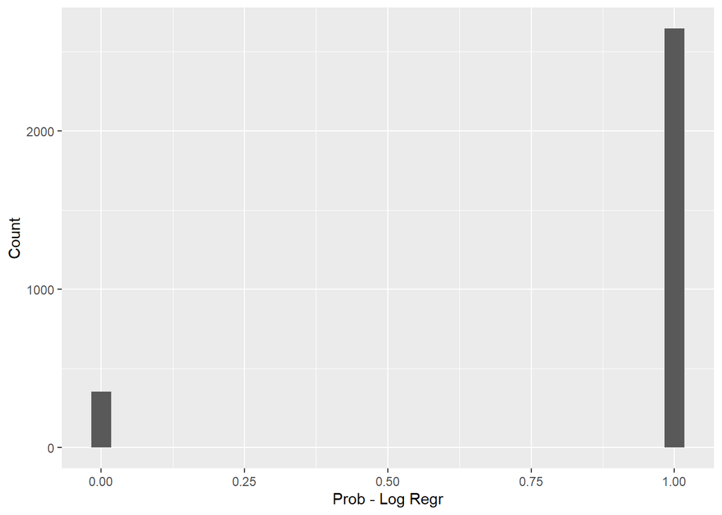

```r
qplot(x = log.fit$fitted.values) + ylab ("Count") + xlab("Prob - Log Regr")
```

Your response here: The estimated probabilities from the logistic regression for any individual are either 0% or 100% since the model is sure about it. Moreover, the model classifies 2646 individuals as adults and 354 as non-adults, reflecting our data accurately.

```r
######## END OF HOMEWORK 3 #######
```